# Hello C++

## Writing a Simple C++ Program

Every C++ program contains one or more functions, one of which must be named main.

- The main function is required to have a return type of int

```python
int main()
{
    return 0;
}
```

### A function definition has four elements:

a return type, a function name, a (possibly empty) parameter list enclosed in parentheses, and a function body

- a return, which is a statement that terminates a function
- When a return statement includes a value, the value returned must have a type that is compatible with the return type of the function. In this case, the return type of main is ***int*** and the return value is 0, which is an int.

***On most systems, the value returned from main is a status indicator. A return value of 0 indicates success. A nonzero return has a meaning that is defined by the system. Ordinarily a nonzero return indicates what kind of error occurred***

# Compiling and Executing Our Program

- Having written the program, we need to compile it. Compiling depends on your operating system and compiler.
- Many PC-based compilers are run from an integrated development environment (IDE)
- Most compilers, including those that come with an IDE, provide a commandline interface.

Diffrecnt compiler use diffrent source file (.cc | .cxx | .cpp | .cp | .c)

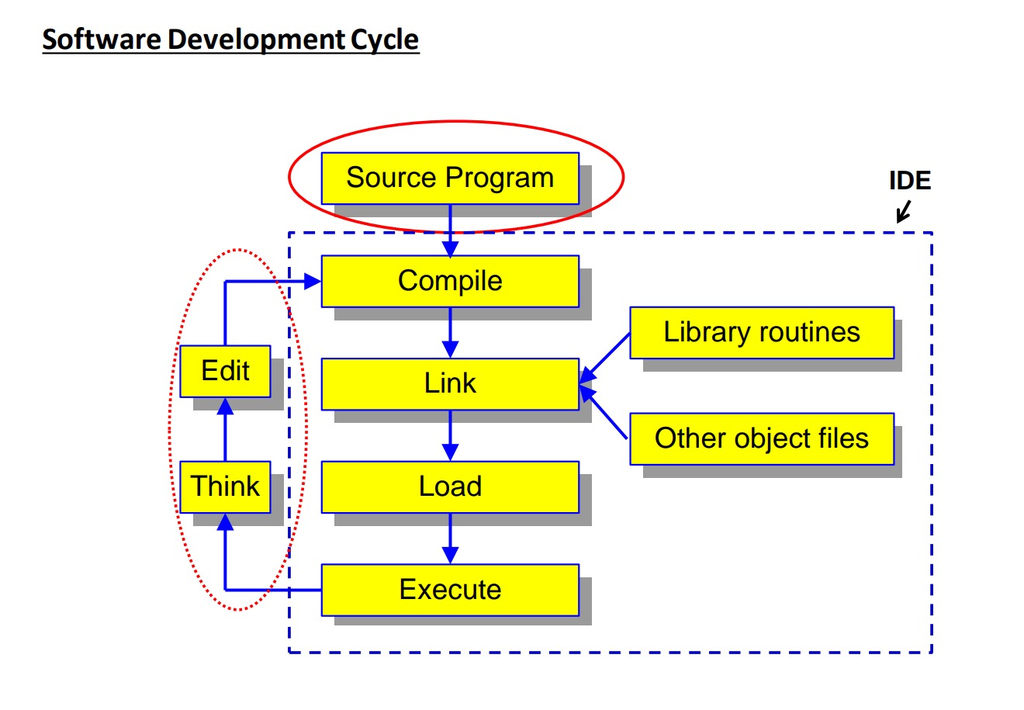

#### Running the Compiler from the Command Line (Linux)

nano hello_c++.cpp

g++ hello_c++.cpp

./a.out

**g++ is a compiler that generate an executable file a.out**

g++ -o hello_c++ hello_c++.cc

**The -o is an argument to the compiler and names the file in which to put the executable file**

# A First Look at Input/Output

The C++ language does not define any statements to do input or output (IO). Instead, C++ includes an extensive standard library that provides IO (and many other facilities). iostream library are two types named istream and ostream, which represent input and output streams.

- A stream is a sequence of characters read from or written to an IO device. The term stream is intended to suggest that the characters are generated, or consumed, sequentially over time ( ^_^ LOL!!!!)

### Standard Input and Output Objects

#### The library defines four IO objects

1. cin >>> standard input (istream object)
2. cout >>> standard output (ostream object)
3. cerr >>> standard error, for warning and error messages (ostream object)
4. clog >>> general information about the execution of the program (ostream object)

`Ordinarily, the system associates each of these objects with the window in which the program is executed So, when we read from cin, data are read from the window in which the program is executing, and when we write to cout, cerr, or clog, the output is written to the same window`

```python
#include <iostream>
int main()
{
    std::cout << "Enter two numbers:" << std::endl;
    int v1 = 0, v2 = 0;
    std::cin>> v1 >> v2;
    std::cout << "The sum of " << v1 << " and " << v2
              << " is " << v1 + v2 << std::endl;
    return 0;
}
main();
```

```
Enter two numbers:
1
2
The sum of 1 and 2 is 3
```